# Data Import & Export

## The `read.table` Family

| Function | Separator | Header |
| --- | --- | --- |
| `read.table()` | white space | `FALSE` |
| `read.csv()` | `,` (comma) | `TRUE` |
| `read.delim()` | `\t` (tab) | `TRUE` |

- All are wrappers around `read.table()` with different defaults
- Key arguments: `sep`, `header`, `stringsAsFactors`, `na.strings`

## Tab-Delimited Files (TSV)

Raw file `DNase.tsv`:

```
"Run"   "conc"  "density"
"1" 0.04882812  0.017
"1" 0.04882812  0.018
"1" 0.1953125   0.121
"1" 0.1953125   0.124
```

- Fields separated by **tab** characters
- Header row present
- Values optionally quoted

## Reading TSV Files

```r
dnase <- read.delim("../data/DNase.tsv", header = TRUE)
head(dnase, 4)
```

```
  Run       conc density
1   1 0.04882812   0.017
2   1 0.04882812   0.018
3   1 0.19531250   0.121
4   1 0.19531250   0.124
```

## What Happens with Wrong Settings?

Using `read.csv()` on a tab-delimited file:

```r
wrong <- read.csv("../data/DNase.tsv", header = TRUE)
head(wrong, 3)
```

```
      Run.conc.density
1 1\t0.04882812\t0.017
2 1\t0.04882812\t0.018
3  1\t0.1953125\t0.121
```

The entire row becomes a single column — the comma separator doesn’t match tabs.

## Comma-Separated Files (CSV)

Raw file `ChickWeight.csv`:

```
"weight","Time","Chick","Diet"
42,0,"1","1"
51,2,"1","1"
59,4,"1","1"
```

- Fields separated by **commas**
- Quoted strings, numeric values unquoted

## Reading CSV Files

```r
chick <- read.csv("../data/ChickWeight.csv")
head(chick, 4)
```

```
  weight Time Chick Diet
1     42    0     1    1
2     51    2     1    1
3     59    4     1    1
4     64    6     1    1
```

```r
str(chick)
```

```
'data.frame':   578 obs. of  4 variables:
 $ weight: int  42 51 59 64 76 93 106 125 149 171 ...
 $ Time  : int  0 2 4 6 8 10 12 14 16 18 ...
 $ Chick : int  1 1 1 1 1 1 1 1 1 1 ...
 $ Diet  : int  1 1 1 1 1 1 1 1 1 1 ...
```

## Space-Delimited Files

Raw file `ChickWeight_feed.txt`:

```
weight feed
179 horsebean
160 horsebean
136 horsebean
227 horsebean
```

- Fields separated by **spaces**
- Simple header, no quoting

## Reading Space-Delimited Files

```r
feed <- read.table("../data/ChickWeight_feed.txt",
                    header = TRUE,
                    stringsAsFactors = TRUE)
head(feed, 4)
```

```
  weight      feed
1    179 horsebean
2    160 horsebean
3    136 horsebean
4    227 horsebean
```

```r
str(feed)
```

```
'data.frame':   71 obs. of  2 variables:
 $ weight: int  179 160 136 227 217 168 108 124 143 140 ...
 $ feed  : Factor w/ 6 levels "casein","horsebean",..: 2 2 2 2 2 2 2 2 2 2 ...
```

`read.table()` handles space-delimited files by default.

## Reading Excel Files

```r
library(readxl)
feed_xl <- read_excel("../data/ChickWeight_feed.xlsx",
                       sheet = 1)
head(feed_xl, 4)
```

```
# A tibble: 4 × 2
  weight feed
   <dbl> <chr>
1    179 horsebean
2    160 horsebean
3    136 horsebean
4    227 horsebean
```

- `read_excel()` returns a **tibble** (enhanced data frame)
- Specify sheet by number or name

## BED Files — No Header

Raw file `genes.bed`:

```
chr1    35302   47518   .   19  +
chr1    48727   51793   .   19  -
chr1    53339   73160   .   18  -
```

- Tab-delimited, **no header row**
- Standard genomic format: chrom, start, end, name, score, strand

## Reading Files Without Headers

```r
genes <- read.table("../data/genes.bed", header = FALSE)
head(genes, 3)
```

```
    V1    V2    V3 V4 V5 V6
1 chr1 35302 47518  . 19  +
2 chr1 48727 51793  . 19  -
3 chr1 53339 73160  . 18  -
```

Column names default to `V1`, `V2`, … — assign meaningful names:

```r
colnames(genes) <- c("chrom", "start", "end",
                      "name", "score", "strand")
head(genes, 3)
```

```
  chrom start   end name score strand
1  chr1 35302 47518    .    19      +
2  chr1 48727 51793    .    19      -
3  chr1 53339 73160    .    18      -
```

## Alternative: Set Names During Import

```r
genes <- read.table(
  "../data/genes.bed", header = FALSE,
  col.names = c("chrom", "start", "end",
                 "name", "score", "strand")
)
head(genes, 3)
```

```
  chrom start   end name score strand
1  chr1 35302 47518    .    19      +
2  chr1 48727 51793    .    19      -
3  chr1 53339 73160    .    18      -
```

## Inspecting Imported Data

| Function | Purpose |
| --- | --- |
| `head(df)` | First 6 rows |
| `tail(df)` | Last 6 rows |
| `str(df)` | Structure (types, dimensions) |
| `summary(df)` | Statistical summary per column |
| `dim(df)` | Number of rows and columns |
| `nrow(df)`, `ncol(df)` | Row / column count |
| `colnames(df)` | Column names |

## Data Frames vs Tibbles

```r
library(tibble)
chick_tb <- as_tibble(chick)
chick_tb
```

```
# A tibble: 578 × 4
   weight  Time Chick  Diet
    <int> <int> <int> <int>
 1     42     0     1     1
 2     51     2     1     1
 3     59     4     1     1
 4     64     6     1     1
 5     76     8     1     1
 6     93    10     1     1
 7    106    12     1     1
 8    125    14     1     1
 9    149    16     1     1
10    171    18     1     1
# ℹ 568 more rows
```

Tibbles print more compactly and show column types.

## Quick Exploratory Plots

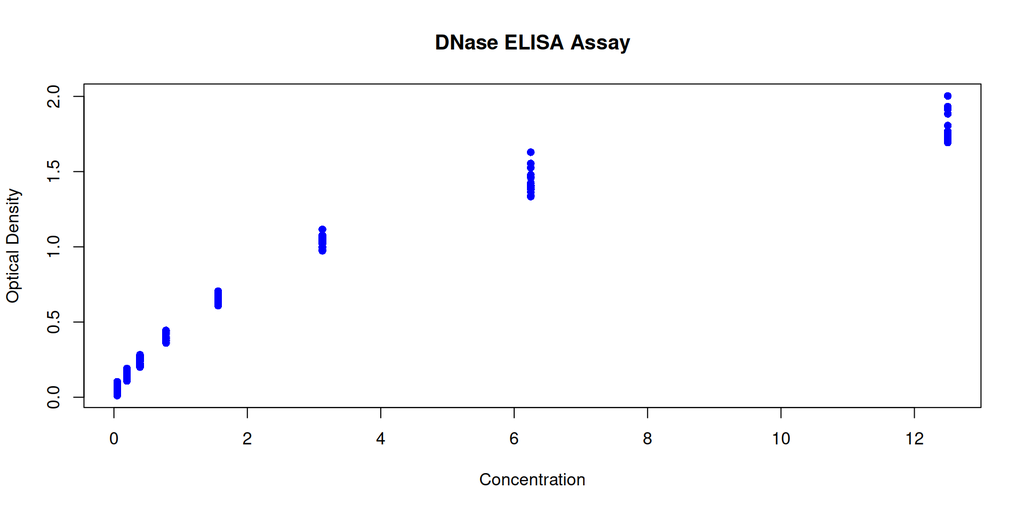

```r
plot(dnase$conc, dnase$density,
     xlab = "Concentration", ylab = "Optical Density",
     main = "DNase ELISA Assay", col = "blue", pch = 16)
```

## Boxplots for Grouped Data

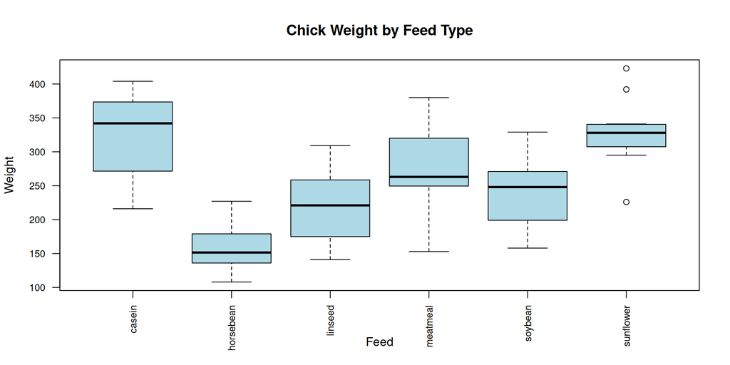

```r
boxplot(weight ~ feed, data = feed,
        main = "Chick Weight by Feed Type",
        xlab = "Feed", ylab = "Weight",
        col = "lightblue", las = 2, cex.axis = 0.8)
```

## Histograms

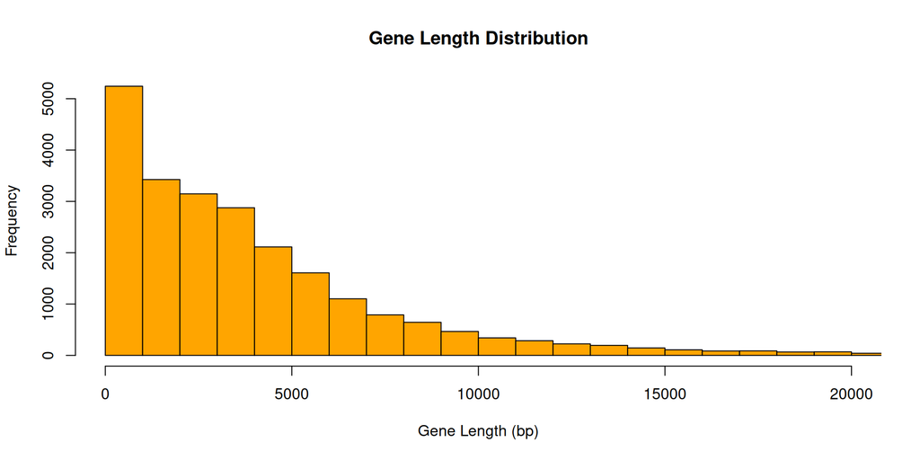

```r
genes$length <- genes$end - genes$start
hist(genes$length, breaks = 100, col = "orange",
     main = "Gene Length Distribution",
     xlab = "Gene Length (bp)", xlim = c(0, 20000))
```

## Handling Missing Values

Raw file with `NA` values:

```
Run conc    density
1   0.04882812  0.017
1   0.04882812  0.018
1   0.1953125   NA
```

Missing values can also appear as empty fields or custom strings.

```r
d <- read.delim("../data/DNase_missing_values_2.tsv")
mean(d$density)             # NA propagates!
```

```
[1] NA
```

```r
mean(d$density, na.rm = TRUE)  # exclude NAs
```

```
[1] 0.7281329
```

## Removing Rows with NA

```r
d <- read.delim("../data/DNase_missing_values_2.tsv")
nrow(d)
```

```
[1] 176
```

```r
d_clean <- na.omit(d)
nrow(d_clean)
```

```
[1] 173
```

- `na.rm = TRUE` — ignore NAs in calculations
- `na.omit()` — remove entire rows containing any NA
- `na.strings` argument in `read.table()` — define custom NA representations

## Exporting Data

```r
# CSV (comma-separated)
write.csv(feed, "output.csv", row.names = FALSE)

# TSV (tab-separated)
write.table(feed, "output.tsv", sep = "\t",
            row.names = FALSE)
```

- `row.names = FALSE` — don’t write row numbers to file
- Check output in a text editor to verify format

## Saving R Objects

```r
# Save any R object in binary format
saveRDS(d_clean, "work_dir/clean_data.rds")

# Load it back
loaded <- readRDS("work_dir/clean_data.rds")
```

- Preserves exact R object (types, factors, attributes)
- More compact than text formats
- Not human-readable

## Summary

| Task | Function |
| --- | --- |
| Read CSV | `read.csv()` |
| Read TSV | `read.delim()` |
| Read any delimited | `read.table(sep=, header=)` |
| Read Excel | `readxl::read_excel()` |
| Inspect | `head()`, `str()`, `summary()` |
| Handle NAs | `na.rm=TRUE`, `na.omit()` |
| Write CSV/TSV | `write.csv()`, `write.table()` |
| Save/load R objects | `saveRDS()`, `readRDS()` |